# Ford GoBike Dataset Explanation Presentation

## by (Giwa Temitopeoluwa Hafsat)

## Investigation Overview

> This presentation is to show how the age of users,their gender,their ride duration might affect how consistent they are with Ford GoBike sharing system i.e the user type(customer or subscriber).

> Here are the key insights I arrived at in my data exploration:
- There were more of subscribers than customers in february 2019 which is a really great deal for the bike sharing system.
- More males rented bikes than other genders
- Most bike users spend between 0 and 60 minutes while taking a ride with the bikes
- The bike sharing system has more bike users on thursdays and even on weekdays in general
- Most users are between the ages of 25 and 40 years old
- Customers spend more time on rides before getting to their destinations
- Users take more time before dropping the bikes are the nearest end stations on weekends
- There is a weak negative relationship between age and ride duration of customers i.e the higher their age,the lower their ride durations
- There is a weak positive relationship between age and ride duration of subscribers i.e the higher their age,the higher their ride durations

## Dataset Overview

> The dataset was gathered for the rides in February 2019.It is made up of 183412 rows and 16 columns where 9 of the columns are numeric in nature,5 are categorical while the rest are time format.

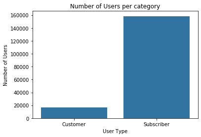

```python
#plotting a bar chart of comparison of customers and subscribers
color = sb.color_palette()[0]
sb.countplot(data = ford_copy,x = 'user_type',color = color)
plt.title('Number of Users per category')
plt.xlabel('User Type')
plt.ylabel('Number of Users');
```

# Observations

From the plot,it's obvious that there were more of subscribers than customers in february 2019 which is a really great deal for the bike sharing system.

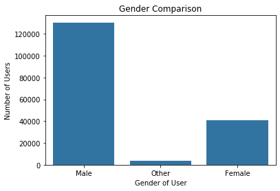

```python
#plotting a bar plot that shows comparison of gender counts for trips in feb 2019
sb.countplot(data = ford_copy,x = 'member_gender',color = color)
plt.title('Gender Comparison')
plt.xlabel('Gender of User')
plt.ylabel('Number of Users');
```

# Observations

From the plot,we can see that more males rented bikes than other genders.

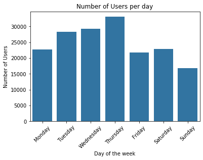

```python
#plotting a bar plot for comparison of user counts per day
sb.countplot(data = ford_copy,x = 'day',color = color)
plt.xticks(rotation = 45)
plt.title('Number of Users per day')
plt.xlabel('Day of the week')
plt.ylabel('Number of Users');
```

# Observations

- It is obvious that the bike sharing system has more bike users on thursdays and even on weekdays in general

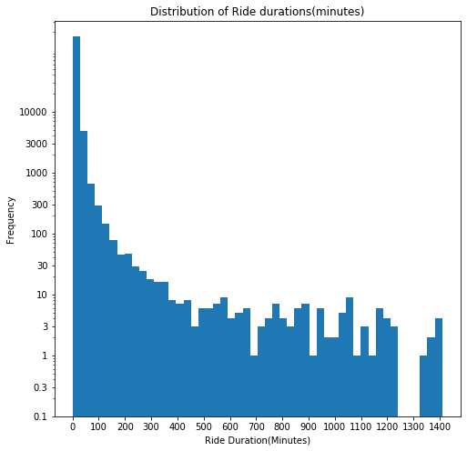

```python
#plotting a histogram to show the distribution of trip duration in feb 2019
plt.figure(figsize = (8,8))
xtick = np.arange(0,ford_copy['trip_duration_in_minutes'].max(),100)
ytick = [0.1,0.3,1,3,10,30,100,300,1000,3000,10000]
plt.hist(x = ford_copy['trip_duration_in_minutes'],bins = 50,log = True)
plt.title('Distribution of Ride durations(minutes)')
plt.xlabel('Ride Duration(Minutes)')
plt.ylabel('Frequency');
plt.xticks(xtick,xtick)
plt.yticks(ytick,ytick);
```

# Observations

1. The distribution of the ride durations is very much rightly skewed i.e it doesn't follow a normal distribution
2. Most bike users spend between 0 and 60 minutes while taking a ride with the bikes.
3. There are also outliers in the ride durations roughly between 1300 minutes and 1400 minutes

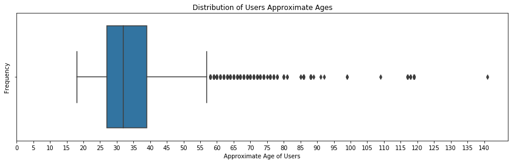

```python
#plotting a boxplot to show the distribution of user ages
plt.figure(figsize = (15,4))
xtick = np.arange(0,ford_copy['member_approximate_age'].max(),5)
sb.boxplot(x = ford_copy['member_approximate_age'])
plt.xticks(xtick,xtick)
plt.title('Distribution of Users Approximate Ages')
plt.xlabel('Approximate Age of Users')
plt.ylabel('Frequency');
```

# Observations

Most users are between the ages of 25 and 40

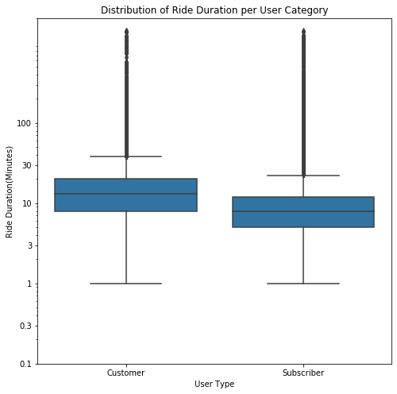

```python
#boxplots for comparison of distribution of ride duration for each user type
plt.figure(figsize = (8,8))
sb.boxplot(data = ford_copy, x = 'user_type', y = 'trip_duration_in_minutes',color = color)
plt.yscale('log')
plt.yticks([0.1,0.3,1,3,10,30,100],[0.1,0.3,1,3,10,30,100])
plt.title('Distribution of Ride Duration per User Category')
plt.xlabel('User Type')
plt.ylabel('Ride Duration(Minutes)');
```

# Observations

Customers spend more time on rides before getting to their destinations

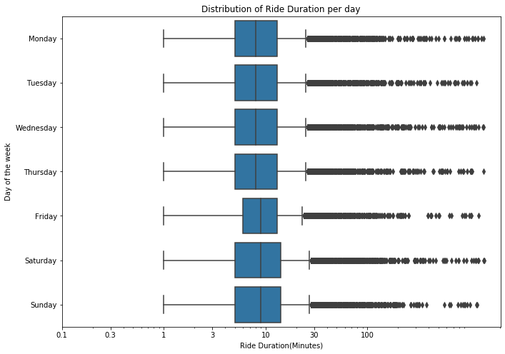

```python
#boxplots for comparison of distribution of ride duration per day
plt.figure(figsize = (11,8))
sb.boxplot(data = ford_copy, x = 'trip_duration_in_minutes', y = 'day',color = color)
plt.xscale('log')
plt.xticks([0.1,0.3,1,3,10,30,100],[0.1,0.3,1,3,10,30,100])
plt.title('Distribution of Ride Duration per day')
plt.ylabel('Day of the week')
plt.xlabel('Ride Duration(Minutes)');
```

# Observations

Users take more time before dropping the bikes are the nearest end stations on weekends

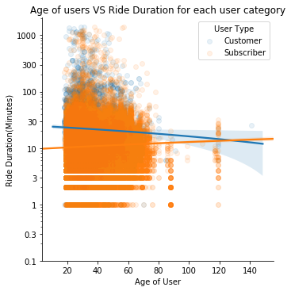

```python
#plotting relationships between age of users and their ride durations with respect to the user type
ytick = [0.1,0.3,1,3,10,30,100,300,1000]
sb.lmplot(data = ford_copy,x = 'member_approximate_age',y = 'trip_duration_in_minutes',hue = 'user_type',scatter_kws={'alpha':0.1},legend = False)
plt.title('Age of users VS Ride Duration for each user category')
plt.xlabel('Age of User')
plt.ylabel('Ride Duration(Minutes)')
plt.yscale('log')
plt.legend(title = 'User Type')
plt.yticks(ytick,ytick);
```

# Observations

1. There is a weak negative relationship between age and ride duration of customers i.e the higher their age,the lower their ride durations
2. There is a weak positive relationship between age and ride duration of subscribers i.e the higher their age,the higher their ride durations

# References

- [Trip Advisor](https://www.tripadvisor.com/Attraction_Review-g60713-d12951811-Reviews-Ford_GoBike-San_Francisco_California.html)
- [Ford Website](https://www.ford.com/)
- [Tom's Blog](https://www.tomsofmaine.com/good-matters/thinking-sustainably/benefits-bike-sharing-you-and-planet)